# Máster en Data Science - Machine Learning

# Explicabilida del modelo con SHAP

Autor: Ramón Morillo Barrera

## Dataset: Application data

En este notebook se llevará a cabo la explicabilidad del modelo con SHAP, este apartado es de gran importancia ya que en un caso real los clientes que fueran rechazados en la concesión de un crédito bancario, tienen el derecho de saber el motivo. Es por ello que el modelo tiene que ser capaz de explicar tanto a nivel global como a nivel local (individual) como afectan sus diversas variables a la decisión final.

Por ello, en este apartado intentaré explicar cómo el modelo identifica los impagos, considerando la importancia de las variables y la dirección en la que estas influyen, ya sea aumentando o disminuyendo la probabilidad de que un individuo sea clasificado como impago. Aunque no se logre una precisión absoluta debido a la naturaleza no lineal del modelo, buscaré interpretar de la mejor manera posible cómo asigna las probabilidades basándose en los valores de las variables.

Este notebook contendrá:

- Aplicación del modelo Shap
- Explicabilidad global
- Explicabilidad local

### Librerías

```python
# Librerías
import pandas as pd
import numpy as np
import sys
import seaborn as sns
import matplotlib.pyplot as plt
import pickle
from joblib import dump, load

import shap
shap.initjs()

import warnings
warnings.filterwarnings('ignore')

pd.set_option('display.max_columns', 500)
pd.set_option('display.max_rows', 500)
```

### Funciones

```python
sys.path.append('../src')
import funciones_auxiliares as f_aux
sys.path.remove('../src')

# Constante
seed = 12354
```

### Importar datos

```python
df_loan_train = pd.read_csv("../../data_loan_status/processed/df_train_resampled.csv")
df_loan_test = pd.read_csv("../../data_loan_status/processed/df_loan_test_processed.csv")
```

```python
X_train = df_loan_train.drop('TARGET', axis=1)
y_train = df_loan_train['TARGET']

X_test = df_loan_test.drop('TARGET', axis=1)
y_test = df_loan_test['TARGET']

X_train.shape, y_train.shape, X_test.shape, y_test.shape
```

```
((108546, 21), (108546,), (61503, 21), (61503,))
```

## Aplicación del modelo SHAP

Importamos nuestro modelo guardado como .joblib

```python
lgbm = load('../models/lgbm_model.joblib')
```

```python
explainer = shap.TreeExplainer(lgbm)
```

### Generación de valores SHAP

```python
shap_values = explainer.shap_values(X_test)
```

```python
shap_values
```

```
array([[ 0.33738898,  0.54338   , -0.03859865, ...,  0.04174306,
         0.15995229,  0.05676331],
       [-0.59486336, -0.05059731, -0.65767232, ..., -0.10489862,
         1.17049447,  0.02260164],
       [ 0.06469274,  1.3547774 , -0.16262641, ..., -0.10960701,
         0.16566994,  0.03684456],
       ...,
       [ 0.03017311, -0.72035307, -0.37033949, ...,  0.04371692,
         1.20424696, -0.09182379],
       [-0.45491051,  0.02936017,  1.00765996, ...,  0.03474004,
         1.20715964, -0.11706484],
       [ 0.06113412,  0.02852774, -0.95379378, ..., -0.12073699,
         0.61424302,  0.31309458]])
```

He generado los valores SHAP de cada una de las variables del modelo. Estos valores permitirán a SHAP realizar los gráficos de explicabilidad del modelo tanto de forma global como de forma parcial. Podremos relacionar el significado de cada variable con la variable objetivo y ver como influye cada una en nuestro modelo.

## Explicabilidad Global

### Summary plot bar

```
100%|===================| 61418/61503 [03:08<00:00]
```

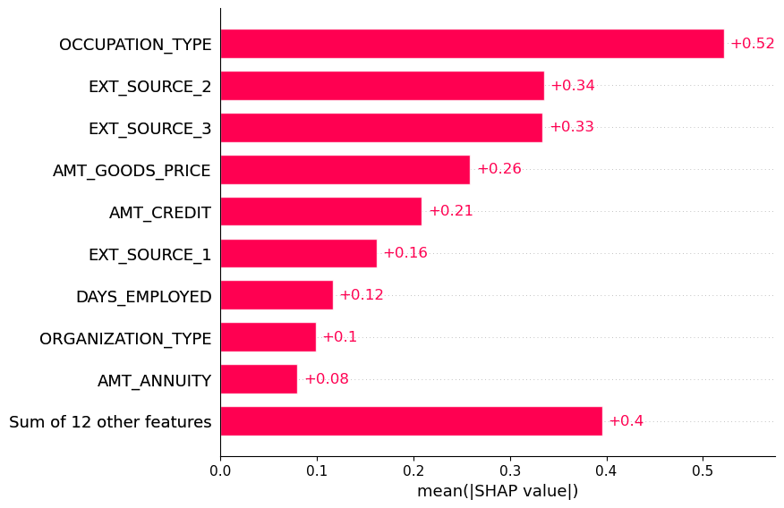

```python
explainer = shap.Explainer(lgbm, X_test)
shap_values = explainer(X_test)
shap.plots.bar(shap_values)
```

Esta gráfica muestra la importancia global de cada variable en el modelo, se crea un gráfico de importancia de característica global, donde la importancia global de cada característica se toma como el valor absoluto medio de esa característica en todas las muestras dadas. Con ello podemos ver que variables como `OCCUPATION_TYPE` que hace referencia al tipo de profesión del individuo, `EXT_SOURCE_2` y `EXT_SOURCE_3` que hacen referencia a un score de una fuente externa muestran una gran importancia en nuestro modelo.

### Summary plot bidireccional

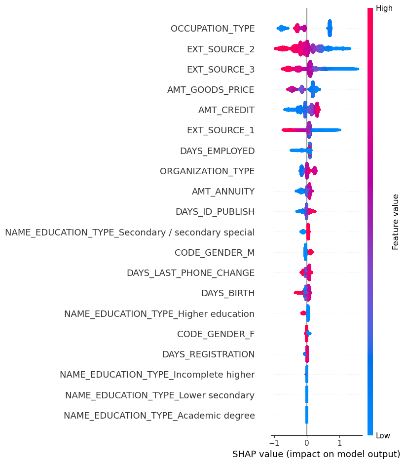

```python
shap.summary_plot(shap_values, X_test)
```

### Force plot

```python
shap_values_exp = explainer(X_test.iloc[:100, :])
shap.force_plot(explainer.expected_value, shap_values_exp.values, features=X_test.iloc[:100, :])
```

## Explicabilidad Global por variables individuales

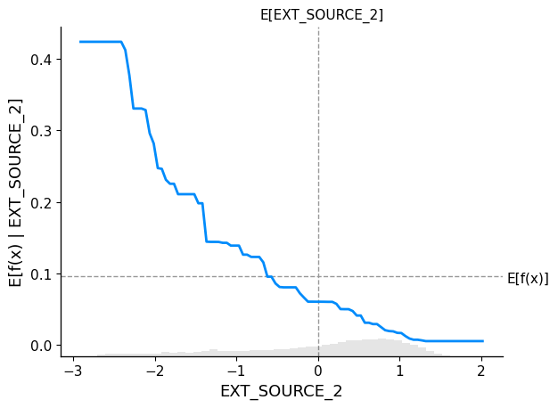

```python
shap.partial_dependence_plot(
    "EXT_SOURCE_2",
    lgbm.predict,
    data=X_test,
    ice=False,
    model_expected_value=True,
    feature_expected_value=True,
)
```

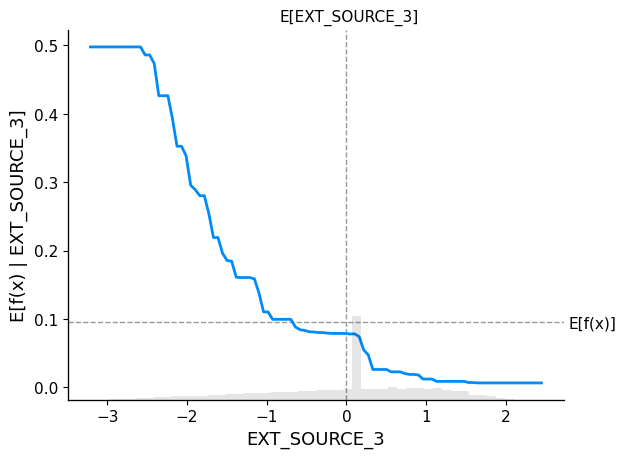

```python
shap.partial_dependence_plot(
    "EXT_SOURCE_3",
    lgbm.predict,
    data=X_test,
    ice=False,
    model_expected_value=True,
    feature_expected_value=True,
)
```

Observamos lo anteriormente mencionado, tanto `EXT_SOURCE_2` como `EXT_SOURCE_3` influyen de manera positiva en la disminución de probabilidad de impago. Cuanto mayores son los valores, progresivamente va disminuyendo esta probabilidad de impago que comentabamos. Puede ser un score crediticio de solvencia generado por alguna compañía externa, aunque no lo podemos saber ya que no tenemos el conocimiento de negocio total. Únicamente son suposiciones para darle un poco más de sentido a este apartado de a explicabilidad.

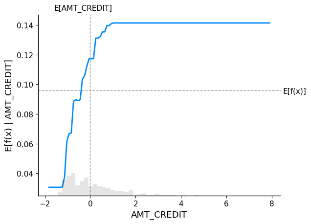

```python
shap.partial_dependence_plot(
    "AMT_CREDIT",
    lgbm.predict,
    data=X_test,
    ice=False,
    model_expected_value=True,
    feature_expected_value=True,
)
```

Igualmente pasa con la variable `AMT_CREDIT`, cuanto mayor es la cantidad de dinero que la entidad prestamista está dispuesta a dar al prestatario, más aumenta la probabilidad de impago por parte del prestatario. Esta interpretación tiene sentido ya que en nuestro sistema económico cotidiano y en la mayoría de contratos de crédito bancario, cuanto mayor es la cuantía a recibir por el prestatario, mayor cantidad de dinero tendrá que devolver en concepto de intereses y mayor será el periodo de devolución de dicho crédito. Es por ello que se asume el riesgo posible y aumenta la probabilidad de impago.

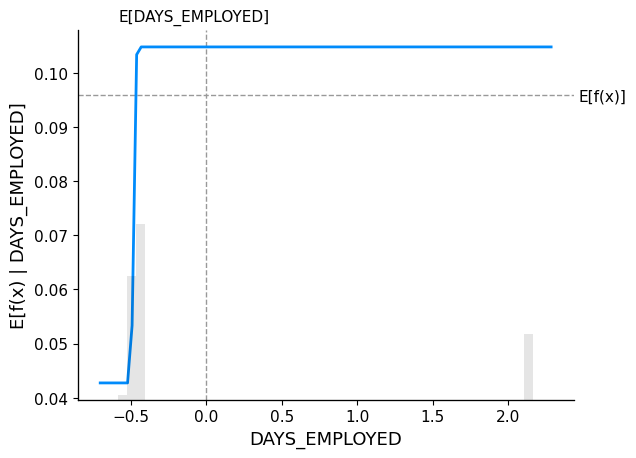

```python
shap.partial_dependence_plot(
    "DAYS_EMPLOYED",
    lgbm.predict,
    data=X_test,
    ice=False,
    model_expected_value=True,
    feature_expected_value=True,
)
```

Como comentamos anteriormente, podría parecer rara la interpretación de la gráfica si no tenemos en cuenta el significado de la variable. En este caso, es indispensable saber que significa cada variable para poder interpretar la explicabilidad del modelo de una forma correcta.

En concreto este gráfico se puede interpretar como, cuantos mayor sea el número de días que lleve el cliente en su actual empleo antes de la solicitud del crédito, menor será su probabilidad de impago del mismo. Esto aporta coherencia de nuevo, ya que si el cliente mantiene un empleo estable a lo largo del tiempo indirectamente significa que es una persona responsable que cumple con sus obligaviones en el trabajo y aún mas importante que tiene unos ingresos estables prolongados a lo largo del tiempo.

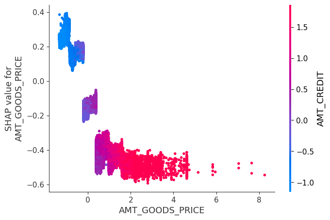

```python
shap_values_array = shap_values.values if isinstance(shap_values, shap.Explanation) else shap_values
shap.dependence_plot('AMT_GOODS_PRICE', shap_values_array, X_test)
```

Este tipo de gráfico y en especial con esta variable nos proporciona bastante información. El gráfico de dependencias parciales relaciona los valores SHAP de la variable con sus valores en general y además discrimina por otra variable que mantenga una cierta correlación mediante el canal del color.

En este caso se observa como a medida que aumenta `AMT_GOODS_PRICE`, es decir, el valor de los bienes de un cliente, disminuye la probabilidad de impago como hemos visto antes. Pero además, cuanto mayor es el valor de los bienes de un cliente, mayor es la cantidad de crédito disponible. Esto podemos interpretarlo gracias a que el color es discriminante hacia la variable `AMT_CREDIT` que hace referencia a la cantidad del crédito. Se podría concluir en que estas dos variables tienen una correlación positiva, y una vez más tiene sentido y coherencia.

## Explicabilidad local

En este caso, SHAP nos brinda la posibilidad de visualizar la influencia de las variables en cada individuo del conjunto de datos y representar gráficamente estos efectos. Esto resulta sumamente interesante para nuestro análisis, ya que nos permite explorar la explicabilidad local del modelo, es decir, comprender cómo y por qué se evalúa cada individuo de una manera específica.

A efectos prácticos, en la realidad podríamos usar esta funcionalidad para proporcionar explicabilidad en un caso concreto en el que se hubiera denegado un crédito bancario a un cliente, en el caso de que el cliente ejerciera sus derechos de saber el o los motivos.

```python
shap_values_exp = explainer(X_test)
shap.force_plot(explainer.expected_value, shap_values_exp.values[0, :], X_test.iloc[0, :])
```

En este caso, se analiza la explicabilidad para un caso particular de un cliente. En este caso observamos que en el gráfico, el "base value" está alrededor de -1.882. Este es el valor inicial de referencia para las predicciones del modelo, antes de considerar las características específicas del individuo.

El modelo ajustó la predicción desde el valor base hasta -1.23. Este valor indica la predicción final del modelo para este individuo. En este caso, una predicción más baja podría estar asociada con solvencia (valor 0 de la variable objetivo).

El color de las variables significa:

- Rojo ("higher"): Variables que aumentaron la probabilidad de impago (valor 1). Por ejemplo, `EXT_SOURCE_1` = -1.721, y otras contribuciones en rojo empujaron la predicción hacia valores más altos (hacia impago).
- Azul ("lower"): Variables que disminuyeron la probabilidad de impago (valor 0). Por ejemplo, `AMT_CREDIT` = -1.152 y `DAYS_EMPLOYED` empujaron la predicción hacia valores más bajos (hacia solvencia).

El tamaño de cada flecha indica la magnitud del impacto de cada variable en la predicción. Variables con flechas más grandes (como `EXT_SOURCE_1` y `EXT_SOURCE_3`) tienen una mayor influencia que las variables con flechas más pequeñas.

Las variables como `EXT_SOURCE_1` y `EXT_SOURCE_3` jugaron un papel clave aumentando el riesgo de impago, mientras que `AMT_CREDIT` y `AMT_ANNUITY` contribuyeron a reducirlo. En este caso, el valor final (-1.23) está más cerca de la base value (-1.882), lo que sugiere que este individuo tiene un riesgo moderado, pero no extremadamente alto, de impago.

```python
shap.force_plot(explainer.expected_value, shap_values_exp.values[2, :], X_test.iloc[2, :])
```

Rojo ("higher"):

- La puntuación del score generada por `EXT_SOURCE_3` = -2.955 tiene mucha importancia y juega un papel muy importante aumentando el riesgo de impago.
- La cantidad del crédito `AMT_CREDIT` = 1.707 también contribuye en cierta medida al aumento de la probabilidad de impago.

Azul ("lower"):

- Variables como el valor de los bienes del cliente `AMT_GOODS_PRICE` = 1.582 contribuyen de manera negativa a la probabilidad de impago del crédito bancario.
- El tiempo que lleve en su actual empleo `DAYS_EMPLOYED` tuvo un pequeño impacto positivo en la solvencia del cliente.

La predicción final de -0.75 indica que este individuo tiene una probabilidad moderadamente alta de impago comparada con el promedio.

```python
shap.force_plot(explainer.expected_value, shap_values_exp.values[10, :], X_test.iloc[10, :])
```

Rojo ("higher"):

- `EXT_SOURCE_1` = -2.109: Este fue el factor más importante que aumentó significativamente la probabilidad de impago.
- `DAYS_ID_PUBLISH` = 1.726: Este indica que la cantidad de días desde la última actualización de un documento de identificación también contribuyó de manera importante al riesgo de impago.
- `AMT_GOODS_PRICE` = -0.2402: El precio de los bienes relacionados con el crédito contribuyó, aunque con un impacto menor, a incrementar el riesgo.

Azul ("lower"): Estas variables disminuyeron la probabilidad de impago (valor 0):

- `OCCUPATION_TYPE` = 0.1052: La ocupación del individuo contribuyó a reducir el riesgo de impago, aunque su impacto fue moderado.
- `ORGANIZATION_TYPE` = 0.04036: El tipo de organización en la que trabaja también ayudó a disminuir ligeramente el riesgo.

La predicción final de -0.80 indica que este individuo tiene una probabilidad moderadamente alta de impago comparada con el promedio.

```python
shap.force_plot(explainer.expected_value, shap_values_exp.values[100, :], X_test.iloc[100, :])
```

La predicción final del modelo para este individuo es -2.83, lo que indica que, comparado con el valor base, la predicción fue empujada hacia valores más bajos. Este individuo es más probable que sea solvente en el pago del crédito bancario.

Rojo ("higher"):

- `DAYS_EMPLOYED` = -0.4536: Este valor indica que el historial de empleo (probablemente pocos días empleados) aumentó ligeramente la probabilidad de impago.
- `AMT_CREDIT` = 0.1483: El monto del crédito solicitado también empujó la predicción hacia un mayor riesgo de impago, pero su impacto es relativamente pequeño.

Azul ("lower"):

- `EXT_SOURCE_3` = 1.123: Una fuente externa (probablemente un score de crédito externo) tuvo un gran impacto positivo, reduciendo significativamente la probabilidad de impago.
- `OCCUPATION_TYPE` = 0.06178: Aunque su efecto es menor, la ocupación del individuo contribuyó ligeramente a disminuir la probabilidad de impago.
- `AMT_GOODS_PRICE` = -0.1795: El precio de los bienes relacionados con el crédito también contribuyó a reducir el riesgo.
- `DAYS_LAST_PHONE_CHANGE`: Este factor tuvo un pequeño impacto positivo en la solvencia del cliente.

La predicción final de -2.83 sugiere que este individuo tiene una baja probabilidad de impago.

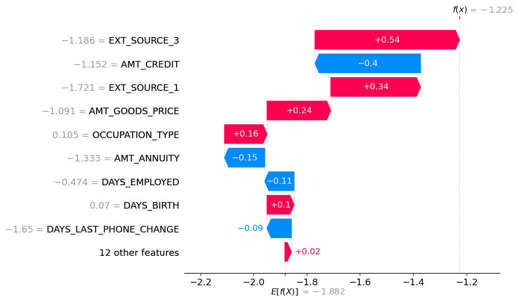

```python
shap_values_exp = shap.Explanation(shap_values, base_values=explainer.expected_value, data=X_test)
shap.plots.waterfall(shap_values_exp[0])
```

Este tipo de gráficas de explicabilidad local es mucho más intuitiva de interpretar, voy a graficar dos ejemplos opuestos en el que se verá una clara diferencia de un cliente que tiene riesgo de impago contra otro que no presenta riesgo de impago.

En primer lugar, vemos igualmente que en las anteriores gráficas 'force_plot' que el valor base es -1.8. Esto significa que si el valor de nuestro cliente está por encima del valor base, mostrará una mayor probabilidad de riesgo de impago y si el valor de nuestro cliente está por debajo del valor base, no mostrará una menor probabilidad de riesgo de impago.

En esta primera gráfica, los valores positivos que se encuentran como rectángulos rojos, son valores para las métricas que empujan la probabilidad de impago al alza. Estos valores en este caso son.

Rojo("higher"):

- `EXT_SOURCE_3`: 0.54
- `EXT_SOURCE_1`: 0.34
- `AMT_GOODS_PRICE`: 0.24
- `OCCUPATION_TYPE`: 0.16
- `DAYS_BIRTH`: 0.1

Estos valores ya han sido explicados con anterioridad, por lo que obviaré su significado. Mientras que los valores negativos que se encuentran representados en rectángulos azules, son valores para las métricas que empujan la probabilidad de impago a la baja.

Azul("lower"):

- `AMT_CREDIT`: -0.4
- `AMT_ANNUITY`: -0.15
- `DAYS_EMPLOYED`: -0.11
- `DAYS_LAST_PHONE_CHANGE`: -0.09

Por tanto, en este cliente en particular, su valor aumenta hasta -1.225 tomando como referencia el valor base (-1.882). Esto supone que la probabilidad de impago de nuestro cliente es moderada. Las variables que más contribuyen a ello son las fuentes externas `EXT_SOURCE_3` y `EXT_SOURCE_1`, aunque la cantidad de crédito concedida `AMT_CREDIT` no sea muy alta ya que empuja la probabilidad a la baja.

Podríamos concluir afirmando que este cliente tienen una probabilidad de impago moderada.

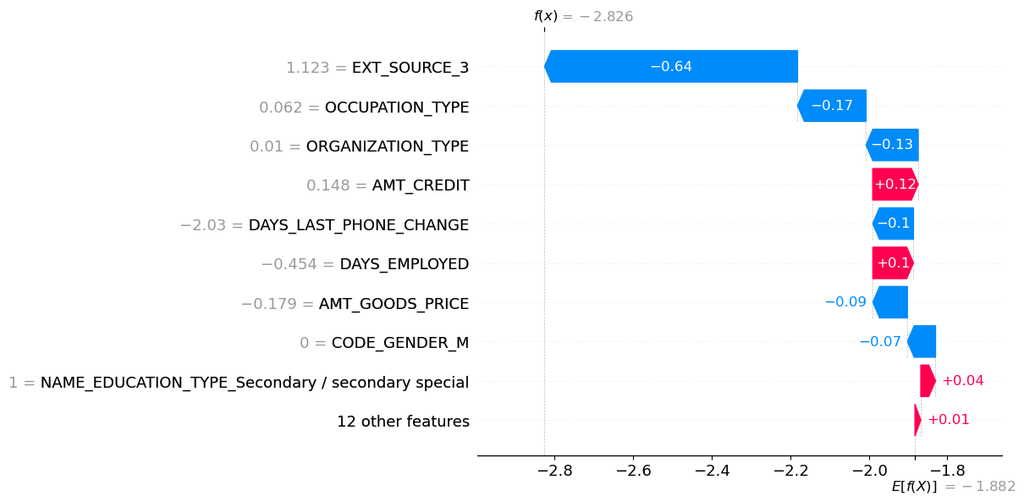

```python
shap.plots.waterfall(shap_values_exp[100])
```

En este caso vemos el otro extremo, nuestro valor base sigue siendo el mismo -1.882, pero en este caso nuestro cliente presenta un valor (-2.826) muy por debajo del valor base. Signica que su probabilidad de impago es bastante baja.

Los valores que contribuyen a aumentar su probabilidad de impago son.

Rojo("higher"):

- `AMT_CREDIT`: 0.12
- `DAYS_EMPLOYED`: 0.1

Los valores que contribuyen a disminuir su probabilidad de impago son.

Azul("lower"):

- `EXT_SOURCE_3`: -0.64
- `OCCUPATION_TYPE`: -0.17
- `ORGANIZATION_TYPE`: -0.13

Me gustan este tipo de gráficos de explicabilidad local ya que podemos imaginarnos un perfil de nuestros clientes sabiendo interpretar los valores expuestos, en este caso particular, en el que nuestro cliente tiene una baja probabilidad de impago y teniendo en cuenta los valores de las métricas observadas podemos intuir que este cliente tiene un buen score crediticio, un buen puesto de trabajo y trabaja en una buena empresa que lo respalda, es por ello que se le ha concedido una mayor cantidad de crédito el cuál esta empuja hacia arriba su probabilidad de impago, aunque no tanto como sus características que la disminuyen.

Simplemente son suposiciones ya que no tengo el contexto de negocio al 100% por lo que no podría tomar una decisión acerca de ello. Solo muestro un ejemplo de la capacidad explicativa de este tipo de gráficos y en concreto de esta librería SHAP.

Ya acabada esta última parte de explicabilidad de mi modelo, procederé a redactar unas conclusiones finales del proyecto completo en el siguiente notebook.